# Assignment 2

CJ

21/03/2018

# Reading in and tidying the survey data

```r
library(tidyverse)
options(warn=-1)
survey <- read_csv("data/survey.csv")
# Renaming the variable names to the questions asked
survey <- rename(survey,
       uni_year = Q1,
       ed_sheeran = Q3,
       fav_genre = Q4,
       internet_time = Q5,
       study_time = Q8,
       tv_stream = Q9,
       sd_degree = Q12,
       coding_exp = Q17,
       study_break = Q18,
       sleep_hours = Q21,
       friend_catchup = Q22,
       age = Q23,
       height = Q24,
       fav_sport = Q25,
       gender = Q26,
       ausopen = Q29,
       unit_struggle = Q30,
       etc1010_like = Q31)

# Removing new line delimiters
survey <- lapply(survey, gsub, pattern = "\n", replacement = "", fixed = TRUE)
# Converting the matrix back to a dataframe as character variables, as it was previously
survey <- as.data.frame(survey)
survey <- data.frame(lapply(survey, as.character), stringsAsFactors=FALSE)

# Removing 64th entry - all NA
survey <- survey[-c(64),]

# Renaming multiple choice question answers
# Replacing uni year answers
survey$uni_year[survey$uni_year=="A"] <- "1st year"
survey$uni_year[survey$uni_year=="B"] <- "2nd year"
survey$uni_year[survey$uni_year=="C"] <- "3rd year"
survey$uni_year[survey$uni_year=="D"] <- "4th year"
survey$uni_year[survey$uni_year=="E"] <- "5th+ year"

# Replacing study time answers
survey$study_time[survey$study_time=="A"] <- "[0, 3)"
survey$study_time[survey$study_time=="B"] <- "[3, 6)"
survey$study_time[survey$study_time=="C"] <- "[6, 9)"
survey$study_time[survey$study_time=="D"] <- "[9, 12)"
survey$study_time[survey$study_time=="E"] <- "12+"

# Single vs. double
survey$sd_degree[survey$sd_degree=="A"] <- "Single"
survey$sd_degree[survey$sd_degree=="B"] <- "Double"

# Struggling with the unit?
survey$unit_struggle[survey$unit_struggle=="A"] <- "not struggling"
survey$unit_struggle[survey$unit_struggle=="B"] <- "struggling"

# Previous coding experience
survey$coding_exp[survey$coding_exp=="A"] <- "prior experience coding"
survey$coding_exp[survey$coding_exp=="B"] <- "no experience coding"

# Liking ETC1010
survey$etc1010_like[survey$etc1010_like=="A"] <- "I like ETC1010"
survey$etc1010_like[survey$etc1010_like=="B"] <- "I don't like ETC1010"

# Gender
survey$gender[survey$gender=="A"] <- "female"
survey$gender[survey$gender=="B"] <- "male"
survey$gender[survey$gender=="C"] <- NA

# Australian Open attendance
survey$ausopen[survey$ausopen=="A"] <- "Attended Australian Open"
survey$ausopen[survey$ausopen=="B"] <- "Didn't attend Australian Open"

# Cleaning genre
# Changing all entries to lower case to make strings easier to filter
survey$fav_genre <- sapply(survey$fav_genre, tolower)
# Removing 'music' and blank spaces from entries, since they add nothing to the data
survey$fav_genre <- gsub('music', '', survey$fav_genre)
survey$fav_genre <- gsub(' ', '', survey$fav_genre)
# Converting variations of r&b, pop, rock and hip-hop to fit the same genre
survey$fav_genre <- gsub('rnb', 'r&b', survey$fav_genre)
survey$fav_genre <- gsub('popular', 'pop', survey$fav_genre)
survey$fav_genre[grepl('hip', survey$fav_genre)] <- 'hip-hop'
survey$fav_genre[grepl('rock', survey$fav_genre)] <- 'rock'
# Removing missing values
survey$fav_genre[22] <- NA
survey$fav_genre[46] <- NA

# Cleaning internet usage - making all entries numeric only and removing extra characters
survey$internet_time <- gsub(" .*$",'', survey$internet_time)
survey$internet_time <- gsub('hrs', '', survey$internet_time)
survey$internet_time <- gsub('HOUR', '', survey$internet_time)
survey$internet_time <- as.numeric(as.character(survey$internet_time))

# Sleep hours
survey <- survey %>%
  mutate(sleep_hours = sub("7;30", "7.5", sleep_hours))
survey$sleep_hours <- as.numeric(as.character(survey$sleep_hours))

# Friend catch up
survey <- survey %>%
  mutate(friend_catchup = sub("3days", "3", friend_catchup))
survey$friend_catchup <- as.numeric(as.character(survey$friend_catchup))

# Age
survey <- survey %>%
  mutate(age = sub("1997", "21", age))
survey$age[63] <- NA
survey$age <- as.numeric(as.character(survey$age))
# Imputing mean to the missing values in the age column
survey <- survey %>%
  mutate(age = ifelse(is.na(age), mean(age, na.rm = TRUE), age))

# Height
survey$height[38] <- NA
survey$height <- as.numeric(as.character(survey$height))
survey <- survey %>%
  mutate(height = ifelse(is.na(height), mean(height, na.rm = TRUE), height))

# Favourite sport
survey$fav_sport <- sapply(survey$fav_sport, tolower)
survey$fav_sport[grepl('swim', survey$fav_sport)] <- 'swimming'
survey$fav_sport[grepl('run', survey$fav_sport)] <- 'running'
survey$fav_sport[32] <- NA
survey$fav_sport[40] <- NA
survey$fav_sport[19] <- NA
```

# Plots

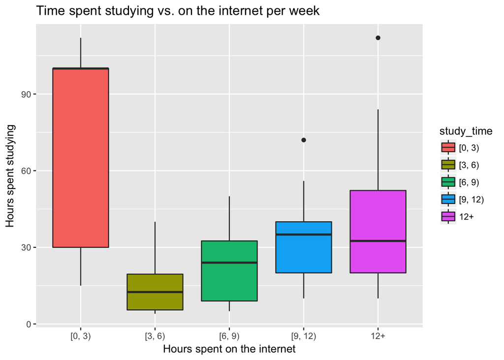

```r
ggplot(data = survey) +
  geom_boxplot(mapping = aes(x = study_time, y = internet_time, fill = study_time)) +
  ylab('Hours spent studying') +
  xlab('Hours spent on the internet') +
  ggtitle('Time spent studying vs. on the internet per week')
```

Perhaps to not much surprise, people who study for less than 3 hours a week spend the most time on the internet. What is interesting is that as people spend more time studying, they also spend more time on the internet - maybe on Moodle or doing online research? Or maybe procrastinating… For those who spend all that time studying, it will be interesting to see how much sleep they actually manage to get.

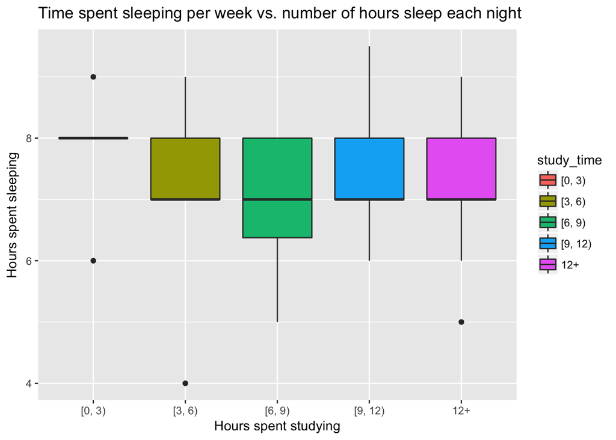

```r
ggplot(data = survey) +
  geom_boxplot(mapping = aes(x = study_time, y = sleep_hours, fill = study_time)) +
  xlab('Hours spent studying') +
  ylab('Hours spent sleeping') +
  ggtitle('Time spent sleeping per week vs. number of hours sleep each night')
```

Surprisingly, even those who study more than 12 hours a week on average don’t sleep more than 8 hours, as they share the same upper quartile as those who study less.

So people can study more but still manage to sleep as much as those who study less? Let’s see if anything else in their life is impacted…

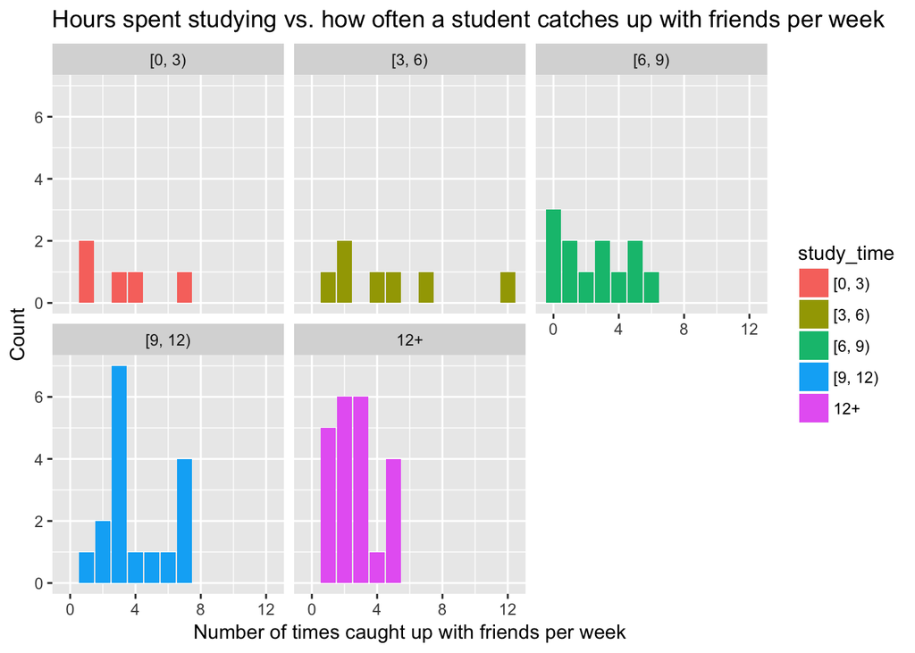

```r
ggplot(data = survey) +
  geom_bar(mapping = aes(x = friend_catchup, fill=study_time)) +
  facet_wrap(~study_time) +
  xlab('Number of times caught up with friends per week') +
  ylab('Count') +
  ggtitle('Hours spent studying vs. how often a student catches up with friends per week')
```

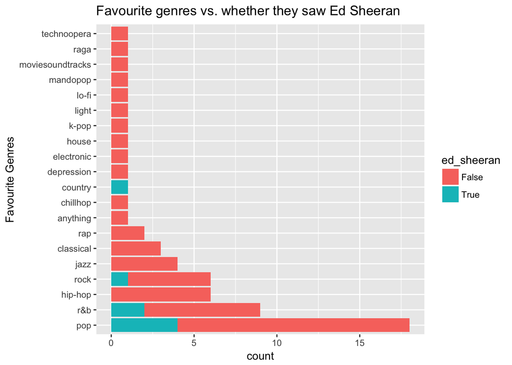

```r
ggplot(data = subset(survey, !is.na(fav_genre))) +
  geom_bar(mapping = aes(x = reorder(fav_genre,fav_genre, function(x)-length(x)), fill = ed_sheeran)) +
  coord_flip() +
  xlab('Favourite Genres') +
  ggtitle('Favourite genres vs. whether they saw Ed Sheeran')
```

We can see that those who attended the Ed Sheeran concert are also those who listen to more commonly accepted as ‘mainstream’ genres - like pop, r&b, rock and country. Those who did not attend appear to love more niche genres and would probably be unimpressed with how non-underground Ed Sheeran is.

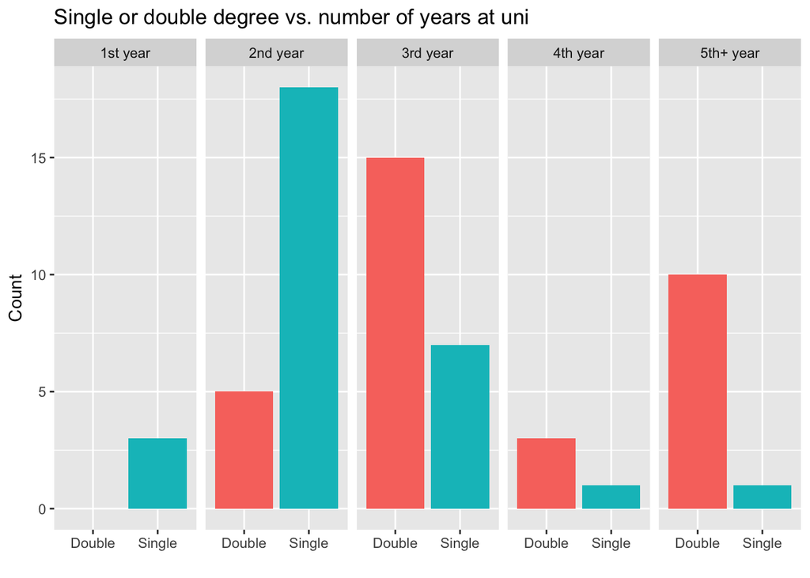

```r
ggplot(data = survey) +
  geom_bar(mapping = aes(x = sd_degree, fill=sd_degree)) +
  facet_wrap(~uni_year, nrow = 1) +
  xlab('') +
  ylab('Count') +
  theme(legend.position = 'none') +
  ggtitle('Single or double degree vs. number of years at uni')
```

Unsurprisingly, most people in their 5th+ year of university are studying double degrees. Most of the students in ETC1010 seem to be in their second or third year though, with significantly less in first and fourth year. There is a rise in the number of students in their 5th+ years taking on the subject - perhaps looking for an ‘easier’ introductory subject to make their final years a little easier.

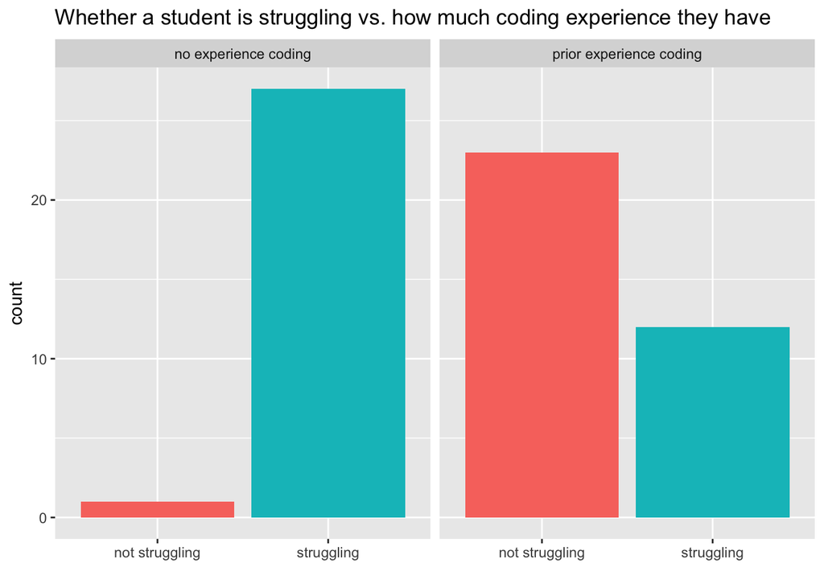

```r
# Examining relationship between previous coding experience and whether a student struggles
ggplot(survey, aes(x=unit_struggle, fill = unit_struggle)) +
  geom_histogram(stat="count") +
  facet_wrap(~coding_exp) +
  xlab('') +
  theme(legend.position = 'none') +
  ggtitle('Whether a student is struggling vs. how much coding experience they have')
```

The histogram shows what we expect - most people without prior coding experience do struggle with the unit; while among those with prior coding experience, most of them do not struggle. What is interesting is there are still over 10 people with prior coding experience that are struggling with the unit - maybe they’ve used different programming languages previously.

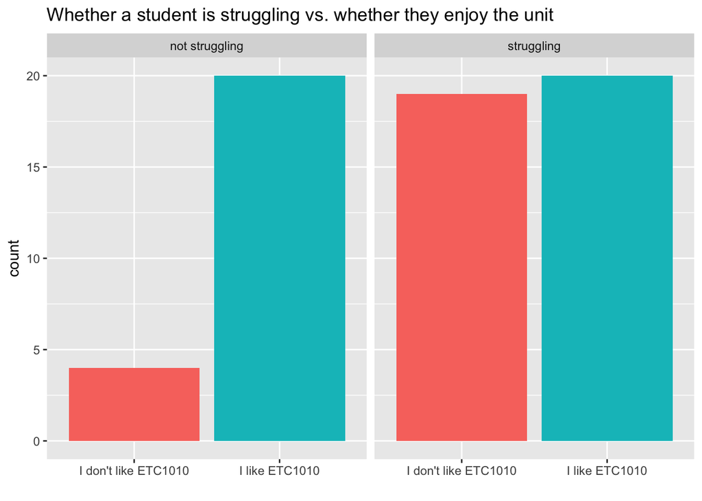

```r
# Do students who struggle dislike ETC1010?
ggplot(survey, aes(x=etc1010_like, fill = etc1010_like)) +
  geom_histogram(stat="count") +
  facet_wrap(~unit_struggle) +
  xlab('') +
  ggtitle('Whether a student is struggling vs. whether they enjoy the unit') +
  theme(legend.position = 'none')
```

For people who do not struggle with the unit, as we expect, most of them like this unit; however, the interesting thing is for people who struggle with the unit, most of them, which is 20, do enjoy the unit. We guess that maybe it is because they are enjoying what they’re learning, despite how difficult it is.

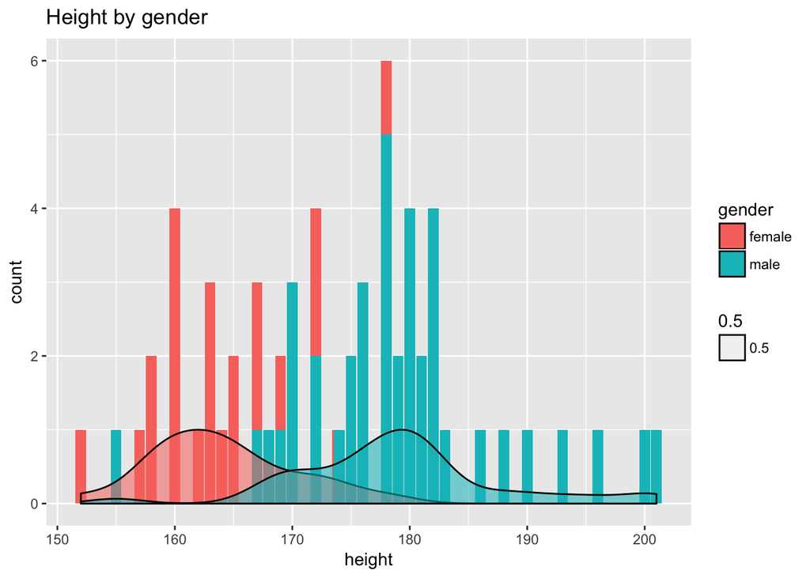

```r
# Making graph for age and height coloured by gender
ggplot(data = subset(survey, !is.na(gender)), aes(x = height, fill = gender)) +
  geom_histogram(stat='count') +
  geom_density(aes(y = ..scaled.., alpha = 0.5)) +
  ggtitle('Height by gender')
```

Generally, male classmates are taller than female classmates. Male classmates’ height is between 167cm to 201 cm (except one whose height is 155cm), with most being around 179cm tall, while female classmates’ height is between 152cm to 172cm (except one whose height is 178cm), with most being around 162cm tall, showing that men are on average taller than females, to not much surprise.

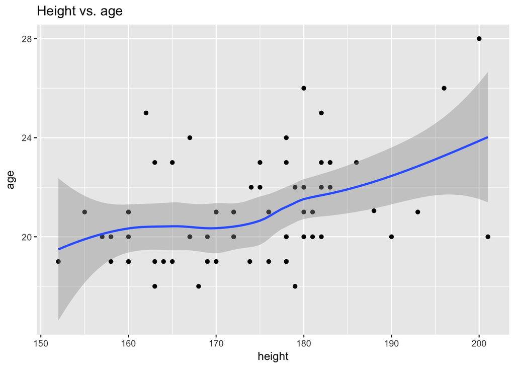

```r
ggplot(data = survey, aes(x = height, y = age)) +
  geom_point() +
  geom_smooth() +
  ggtitle('Height vs. age')
```

From exploring the heights of our classmates further, we can see that there is a positive correlation between height and age, as one would normally expect - as we get older, we also get taller.

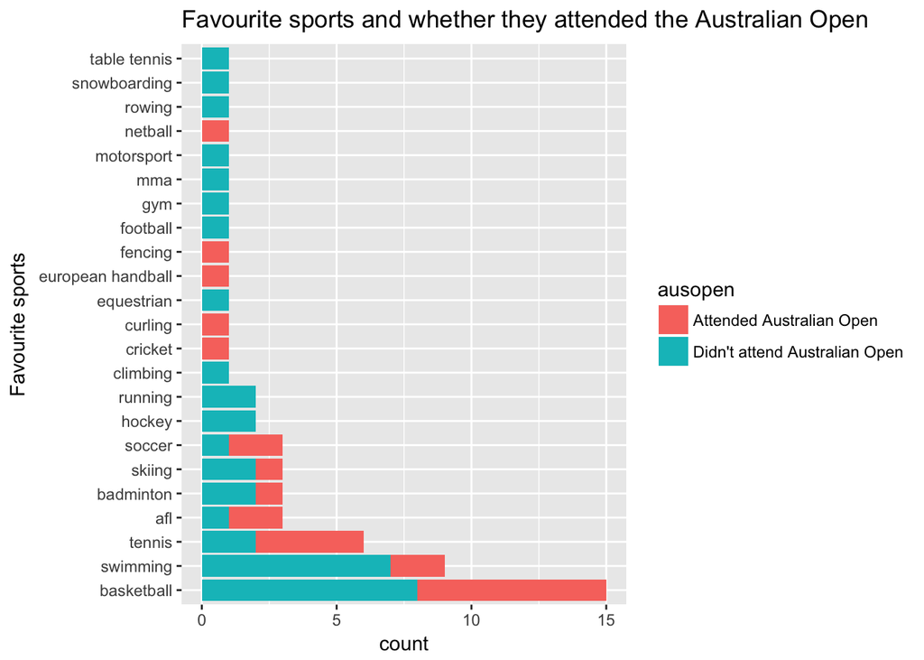

```r
ggplot(data = subset(survey, !is.na(fav_sport))) +
  coord_flip() +
  geom_bar(mapping = aes(x = reorder(fav_sport,fav_sport, function(x)-length(x)), fill=ausopen))+
  xlab('Favourite sports') +
  ggtitle('Favourite sports and whether they attended the Australian Open')
```